# Practical Machine Learning Project

Michael Onizak

January 23, 2017

## **EXCECUTIVE SUMMARY**

This document contains the Practical Machine Learning Project. The goal of this project was to predict the manner in which 6 participants performed some exercise as described below.

Using devices such as Jawbone Up, Nike FuelBand, and Fitbit it is now possible to collect a large amount of data about personal activity relatively inexpensively. These type of devices are part of the quantified self movement - a group of enthusiasts who take measurements about themselves regularly to improve their health, to find patterns in their behavior, or because they are tech geeks. One thing that people regularly do is quantify how much of a particular activity they do, but they rarely quantify how well they do it. In this project, your goal will be to use data from accelerometers on the belt, forearm, arm, and dumbell of 6 participants. They were asked to perform barbell lifts correctly and incorrectly in 5 different ways. More information is available from the website here: http://groupware.les.inf.puc-rio.br/har (see the section on the Weight Lifting Exercise Dataset).

I have used what we have learned in Coursera’s Data Science Course thus far. This will be my reasoning as to what models I chose to use. After choosing the models it was then just a matter of seeing which model had a better accuracy.

## **LOADING DATA**

The training data for this project are available here:

https://d396qusza40orc.cloudfront.net/predmachlearn/pml-training.csv

The test data are available here:

https://d396qusza40orc.cloudfront.net/predmachlearn/pml-testing.csv

The data for this project come from http://groupware.les.inf.puc-rio.br/har.

Velloso, E.; Bulling, A.; Gellersen, H.; Ugulino, W.; Fuks, H. Qualitative Activity Recognition of Weight Lifting Exercises. Proceedings of 4th International Conference in Cooperation with SIGCHI (Augmented Human ’13) . Stuttgart, Germany: ACM SIGCHI, 2013.

Read more: http://groupware.les.inf.puc-rio.br/har#ixzz4WZO1FiKL

First, to run this analysis, we will use the following packages:

```r
library(knitr)
library(caret)
```

```r
library(rpart)
library(rpart.plot)
library(rattle)
library(randomForest)
library(corrplot)
##Setting up a directory, dowloading and reading the file and creating a partition

setwd("~/r.PROJECTS/R_dir")
if(!file.exists("./DSCourse_9_Assignment_1")) dir.create("./DSCourse_9_Assignment_1")
setwd("~/r.PROJECTS/R_dir/DSCourse_9_Assignment_1")
file_Url_train <- "http://d396qusza40orc.cloudfront.net/predmachlearn/pml-training.csv"
file_Url_test  <- "http://d396qusza40orc.cloudfront.net/predmachlearn/pml-testing.csv"
training <- read.csv(url(file_Url_train))
testing  <- read.csv(url(file_Url_test))
inTrain  <- createDataPartition(training$classe, p=0.7, list=FALSE)
train_set <- training[inTrain, ]
test_set  <- training[-inTrain, ]
```

## **Cleaning the Data**

Here I simply cleaned the data for our models.

```r
#Cleaning the data (removing zeros and N/As)
dim(train_set)
```

```
## [1] 13737   160
```

```r
dim(test_set)
```

```
## [1] 5885  160
```

```r
zero_removal <- nearZeroVar(train_set)
train_set <- train_set[, -zero_removal]
test_set  <- test_set[, -zero_removal]

NA_removal <- sapply(train_set, function(x) mean(is.na(x))) > 0.95
train_set <- train_set[, NA_removal==FALSE]
test_set  <- test_set[, NA_removal==FALSE]

train_set <- train_set[, -(1:5)]
test_set  <- test_set[, -(1:5)]

dim(train_set)
```

```
## [1] 13737    54
```

```r
dim(test_set)
```

```
## [1] 5885   54
```

## **Prediction Model Building**

We will now build and test three models; random forest, decision trees, and generalized boost. Which ever model proves most accurate we will use for the quiz predictions.

Lastly a confusion matrix is plotted at the end of each analysis to confirm our model.

```r
set.seed(12345)
random_forest_control <- trainControl(method = "cv",
                          number = 3,
                          verboseIter = FALSE)

random_forest_model <- train(classe ~ .,
                             data = train_set,
                             method = "rf",
                             trControl = random_forest_control)

random_forest_model$finalModel
```

```
##
## Call:
##  randomForest(x = x, y = y, mtry = param$mtry)
##                Type of random forest: classification
##                      Number of trees: 500
## No. of variables tried at each split: 27
##
##         OOB estimate of  error rate: 0.22%
## Confusion matrix:
##      A    B    C    D    E  class.error
## A 3905    1    0    0    0 0.0002560164
## B    7 2647    2    2    0 0.0041384500
## C    0    8 2388    0    0 0.0033388982
## D    0    0    8 2243    1 0.0039964476
## E    0    0    0    1 2524 0.0003960396
```

```r
#Prediction on Test dataset

random_forest_predict <- predict(random_forest_model,
                                 newdata = test_set)

random_forest_confusion_matrix <- confusionMatrix(random_forest_predict,
                                                  test_set$classe)
random_forest_confusion_matrix
```

```
## Confusion Matrix and Statistics
##
##           Reference
## Prediction    A    B    C    D    E
##          A 1673    1    0    0    0
##          B    1 1137    1    0    0
##          C    0    1 1025    3    0
##          D    0    0    0  961    0
##          E    0    0    0    0 1082
##
## Overall Statistics
##
##                Accuracy : 0.9988
##                  95% CI : (0.9976, 0.9995)
##     No Information Rate : 0.2845
##     P-Value [Acc > NIR] : < 2.2e-16
##
##                   Kappa : 0.9985
##  Mcnemar's Test P-Value : NA
##
## Statistics by Class:
##
##                      Class: A Class: B Class: C Class: D Class: E
## Sensitivity            0.9994   0.9982   0.9990   0.9969   1.0000
## Specificity            0.9998   0.9996   0.9992   1.0000   1.0000
## Pos Pred Value         0.9994   0.9982   0.9961   1.0000   1.0000
## Neg Pred Value         0.9998   0.9996   0.9998   0.9994   1.0000
## Prevalence             0.2845   0.1935   0.1743   0.1638   0.1839
## Detection Rate         0.2843   0.1932   0.1742   0.1633   0.1839
## Detection Prevalence   0.2845   0.1935   0.1749   0.1633   0.1839
## Balanced Accuracy      0.9996   0.9989   0.9991   0.9984   1.0000
```

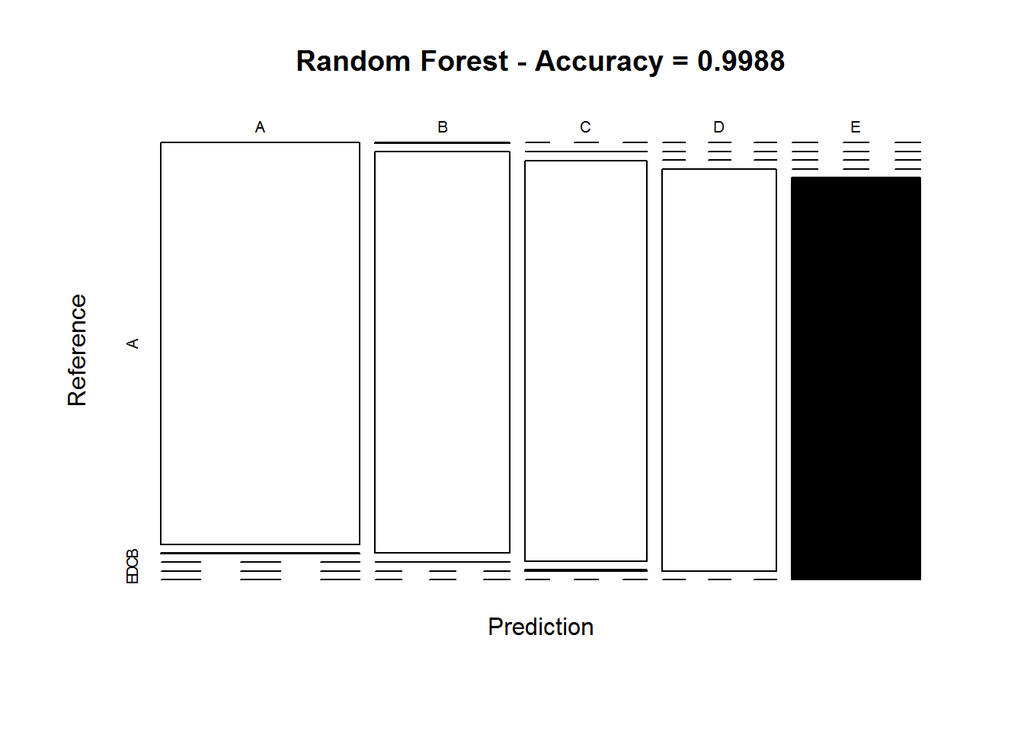

```r
plot(random_forest_confusion_matrix$table,
          col = random_forest_confusion_matrix$byClass,
          main = paste("Random Forest - Accuracy =",
          round(random_forest_confusion_matrix$overall['Accuracy'], 4)))
```

Decision Trees

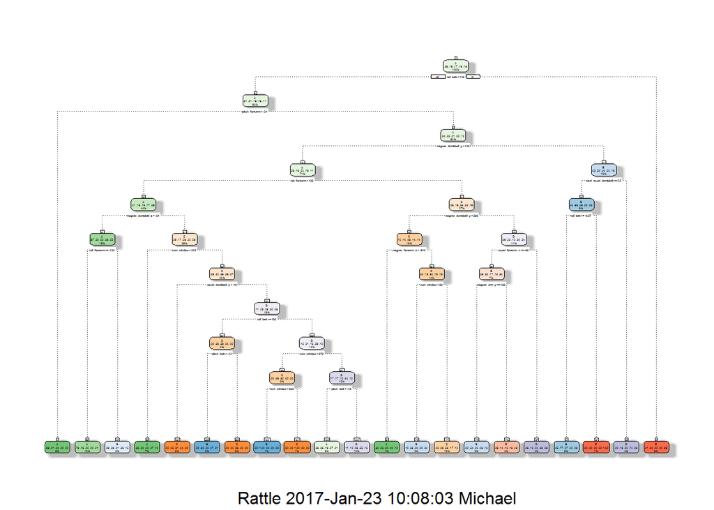

```r
set.seed(12345)
decision_tree_model <- rpart(classe ~ .,
                             data = train_set,
                             method = "class")

fancyRpartPlot(decision_tree_model)
```

```r
#Prediction on Test dataset

decision_tree_predict <- predict(decision_tree_model,
                                 newdata = test_set,
                                 type="class")

decision_tree_confusion_matrix <- confusionMatrix(decision_tree_predict,
                                                  test_set$classe)
decision_tree_confusion_matrix
```

```
## Confusion Matrix and Statistics
##
##           Reference
## Prediction    A    B    C    D    E
##          A 1493  200   43   60   54
##          B   64  688   82   71  103
##          C   14   64  821  167   89
##          D   88  148   63  623  139
##          E   15   39   17   43  697
##
## Overall Statistics
##
##                Accuracy : 0.7344
##                  95% CI : (0.7229, 0.7457)
##     No Information Rate : 0.2845
##     P-Value [Acc > NIR] : < 2.2e-16
##
##                   Kappa : 0.6631
##  Mcnemar's Test P-Value : < 2.2e-16
##
## Statistics by Class:
##
##                      Class: A Class: B Class: C Class: D Class: E
## Sensitivity            0.8919   0.6040   0.8002   0.6463   0.6442
## Specificity            0.9152   0.9326   0.9313   0.9110   0.9763
## Pos Pred Value         0.8070   0.6825   0.7108   0.5872   0.8594
## Neg Pred Value         0.9551   0.9075   0.9567   0.9293   0.9241
## Prevalence             0.2845   0.1935   0.1743   0.1638   0.1839
## Detection Rate         0.2537   0.1169   0.1395   0.1059   0.1184
## Detection Prevalence   0.3144   0.1713   0.1963   0.1803   0.1378
## Balanced Accuracy      0.9035   0.7683   0.8657   0.7786   0.8102
```

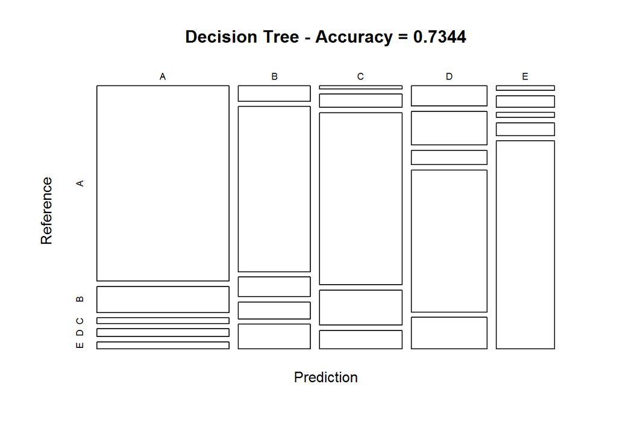

```r
plot(decision_tree_confusion_matrix$table,
            col = decision_tree_confusion_matrix$byClass,
            main = paste("Decision Tree - Accuracy =",
            round(decision_tree_confusion_matrix$overall['Accuracy'], 4)))
```

Generalized Boost Model

```r
set.seed(12345)
boost_model_control <- trainControl(method = "repeatedcv",
                                    number = 5,
                                    repeats = 1)

#Prediction on Test dataset

boost_model_predict  <- train(classe ~ .,
                              data = train_set,
                              method = "gbm",
                              trControl = boost_model_control,
                              verbose = FALSE)
boost_model_predict$finalModel
```

```
## A gradient boosted model with multinomial loss function.
## 150 iterations were performed.
## There were 53 predictors of which 43 had non-zero influence.
```

```r
boost_model_predict <- predict(boost_model_predict,
                               newdata = test_set)

boost_model_confusion_matrix <- confusionMatrix(boost_model_predict, test_set$classe)

boost_model_confusion_matrix
```

```
## Confusion Matrix and Statistics
##
##           Reference
## Prediction    A    B    C    D    E
##          A 1671   11    0    0    0
##          B    3 1114   10    2    1
##          C    0   14 1016   12    0
##          D    0    0    0  949    3
##          E    0    0    0    1 1078
##
## Overall Statistics
##
##                Accuracy : 0.9903
##                  95% CI : (0.9875, 0.9927)
##     No Information Rate : 0.2845
##     P-Value [Acc > NIR] : < 2.2e-16
##
##                   Kappa : 0.9877
##  Mcnemar's Test P-Value : NA
##
## Statistics by Class:
##
##                      Class: A Class: B Class: C Class: D Class: E
## Sensitivity            0.9982   0.9781   0.9903   0.9844   0.9963
## Specificity            0.9974   0.9966   0.9946   0.9994   0.9998
## Pos Pred Value         0.9935   0.9858   0.9750   0.9968   0.9991
## Neg Pred Value         0.9993   0.9947   0.9979   0.9970   0.9992
## Prevalence             0.2845   0.1935   0.1743   0.1638   0.1839
## Detection Rate         0.2839   0.1893   0.1726   0.1613   0.1832
## Detection Prevalence   0.2858   0.1920   0.1771   0.1618   0.1833
## Balanced Accuracy      0.9978   0.9873   0.9925   0.9919   0.9980
```

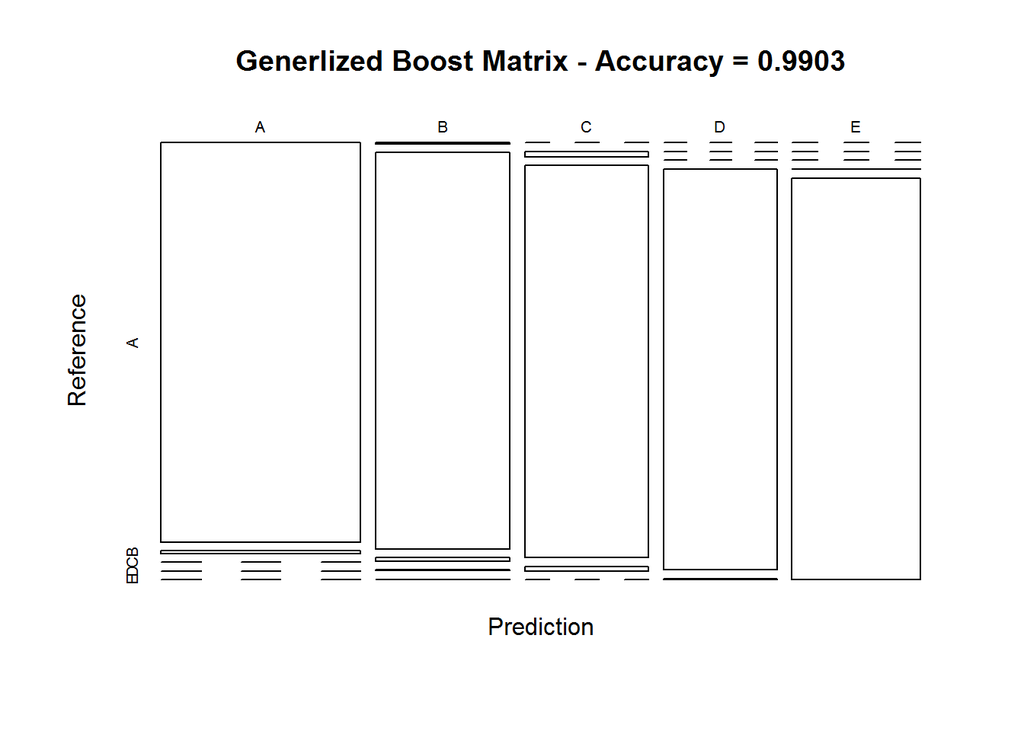

```r
plot(boost_model_confusion_matrix$table,
               col = boost_model_confusion_matrix$byClass,
               main = paste("Generlized Boost Matrix - Accuracy =",
              round(boost_model_confusion_matrix$overall['Accuracy'], 4)))
```

## **Selecting a Model to the Test Data**

Selecting a model to apply to the quiz.

After our testing the Random Forest model bested and will be applied to predict quiz.

```r
quiz_model <- predict(random_forest_model,
                      newdata = testing)
quiz_model
```

```
##  [1] B A B A A E D B A A B C B A E E A B B B
## Levels: A B C D E
```